# Poisson EDA example (W271 Unit 5)

Michael Winton

## Introduction

- Introduce use of a Poisson regression to model a count response variable
- Consider situations in which the conditional distribution of the response variable follow a Poisson distribution
- Using a dataset on executives at large Canadian companies, study interocking directorates (board members serving on each other’s boards)

## Dataset

This example works with the `Ornstein` dataset from the `car` library

```r
# list the top 10 observations in the dataset
head(Ornstein, 10)
```

```
##    assets sector nation interlocks
## 1  147670    BNK    CAN         87
## 2  133000    BNK    CAN        107
## 3  113230    BNK    CAN         94
## 4   85418    BNK    CAN         48
## 5   75477    BNK    CAN         66
## 6   40742    FIN    CAN         69
## 7   40140    TRN    CAN         46
## 8   26866    BNK    CAN         16
## 9   24500    TRN    CAN         77
## 10  23700    MIN     US          6
```

```r
# summary statistics about the dataset
summary(Ornstein)
```

```
##      assets           sector   nation      interlocks
##  Min.   :    62   MIN    :54   CAN:117   Min.   :  0.00
##  1st Qu.:   519   MAN    :48   OTH: 18   1st Qu.:  3.00
##  Median :  1397   AGR    :47   UK : 17   Median :  9.00
##  Mean   :  5978   FIN    :22   US : 96   Mean   : 13.58
##  3rd Qu.:  4326   MER    :20             3rd Qu.: 18.00
##  Max.   :147670   WOD    :19             Max.   :107.00
##                   (Other):38
```

```r
describe(Ornstein)  #more verbose summary stats
```

```
## Ornstein
##
##  4  Variables      248  Observations
## ---------------------------------------------------------------------------
## assets
##        n  missing distinct     Info     Mean      Gmd      .05      .10
##      248        0      240        1     5978     9114    257.8    326.0
##      .25      .50      .75      .90      .95
##    519.0   1397.0   4325.5  13103.1  20047.8
##
## 0 (111, 0.448), 2000 (55, 0.222), 4000 (25, 0.101), 6000 (13, 0.052), 8000
## (9, 0.036), 10000 (6, 0.024), 12000 (4, 0.016), 14000 (4, 0.016), 16000
## (4, 0.016), 18000 (4, 0.016), 20000 (1, 0.004), 22000 (1, 0.004), 24000
## (3, 0.012), 26000 (1, 0.004), 40000 (2, 0.008), 76000 (1, 0.004), 86000
## (1, 0.004), 114000 (1, 0.004), 132000 (1, 0.004), 148000 (1, 0.004)
## ---------------------------------------------------------------------------
## sector
##        n  missing distinct
##      248        0       10
##
## Value        AGR   BNK   CON   FIN   HLD   MAN   MER   MIN   TRN   WOD
## Frequency     47     8     5    22     7    48    20    54    18    19
## Proportion 0.190 0.032 0.020 0.089 0.028 0.194 0.081 0.218 0.073 0.077
## ---------------------------------------------------------------------------
## nation
##        n  missing distinct
##      248        0        4
##
## Value        CAN   OTH    UK    US
## Frequency    117    18    17    96
## Proportion 0.472 0.073 0.069 0.387
## ---------------------------------------------------------------------------
## interlocks
##        n  missing distinct     Info     Mean      Gmd      .05      .10
##      248        0       50    0.997    13.58    15.22      0.0      0.0
##      .25      .50      .75      .90      .95
##      3.0      9.0     18.0     31.0     41.3
##
## lowest :   0   1   2   3   4, highest:  69  77  87  94 107
## ---------------------------------------------------------------------------
```

```r
# show mean value of interlocks per nation|sector
round(with(Ornstein, tapply(interlocks, nation, mean)), 1)
```

```
##  CAN  OTH   UK   US
## 19.6 14.2  8.7  7.0
```

```r
round(with(Ornstein, tapply(interlocks, sector, mean)), 1)
```

```
##  AGR  BNK  CON  FIN  HLD  MAN  MER  MIN  TRN  WOD
##  8.4 53.9  4.8 24.1 12.4  7.0 10.2 12.9 19.2 16.9
```

In the original study, the author performed an OLS regression with the response variable being `interlocks`, the number of interlocks maintained by each firm, on firm’s assets (in millions of dollars), sector of operation, and nation of control.

However, as the variable `interlocks` is a count, a *Poisson* regression model may be more appropriate.

Let’s take a look at the distribution of the `interlocks` variable. We will have to construct this graph in multiple steps.

## Analyis of the Response Variable

```r
# Frequency distribution of the interlocks
tab <- xtabs(~interlocks, data=Ornstein)
str(tab)      # this view is less useful for a table
```

```
##  'xtabs' int [1:50(1d)] 28 19 14 11 8 14 11 6 12 7 ...
##  - attr(*, "dimnames")=List of 1
##   ..$ interlocks: chr [1:50] "0" "1" "2" "3" ...
##  - attr(*, "call")= language xtabs(formula = ~interlocks, data = Ornstein)
```

```r
class(tab)    # check class (so we know what methods and attributes are available)
```

```
## [1] "xtabs" "table"
```

```r
names(tab)    # variable names
```

```
##  [1] "0"   "1"   "2"   "3"   "4"   "5"   "6"   "7"   "8"   "9"   "10"
## [12] "11"  "12"  "13"  "14"  "15"  "16"  "17"  "18"  "19"  "20"  "21"
## [23] "22"  "23"  "25"  "27"  "28"  "29"  "30"  "31"  "32"  "33"  "34"
## [34] "35"  "36"  "39"  "40"  "42"  "43"  "44"  "46"  "48"  "51"  "55"
## [45] "66"  "69"  "77"  "87"  "94"  "107"
```

```r
nrow(tab)
```

```
## [1] 50
```

```r
tab
```

```
## interlocks
##   0   1   2   3   4   5   6   7   8   9  10  11  12  13  14  15  16  17
##  28  19  14  11   8  14  11   6  12   7   4  12   9   8   4   3   6   3
##  18  19  20  21  22  23  25  27  28  29  30  31  32  33  34  35  36  39
##   9   2   4   3   2   3   4   4   5   5   2   2   2   3   1   1   1   1
##  40  42  43  44  46  48  51  55  66  69  77  87  94 107
##   2   1   1   1   1   1   1   1   1   1   1   1   1   1
```

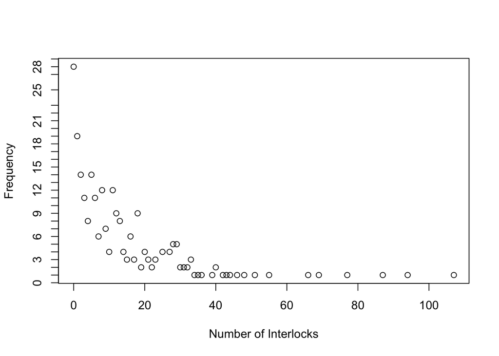

```r
# Record the distinct values of the interlocks
x <- as.numeric(names(tab))  # xtabs stored these as char variables

# Scatter plot of data
plot(x, tab, xlab='Number of Interlocks', ylab='Frequency')
```

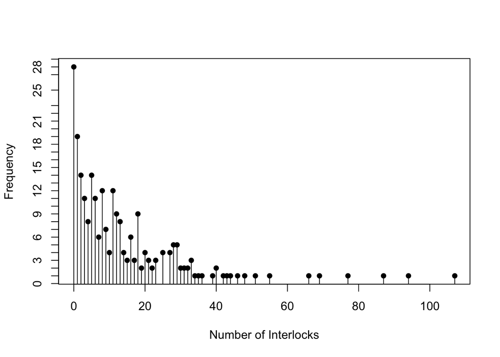

```r
# Bar plot of frequencies
plot(x, tab, type='h',  xlab='Number of Interlocks', ylab='Frequency')
points(x, tab, pch=16)  # decorate top of bars with a point
```

## Quick Analysis of Exploratory Variables

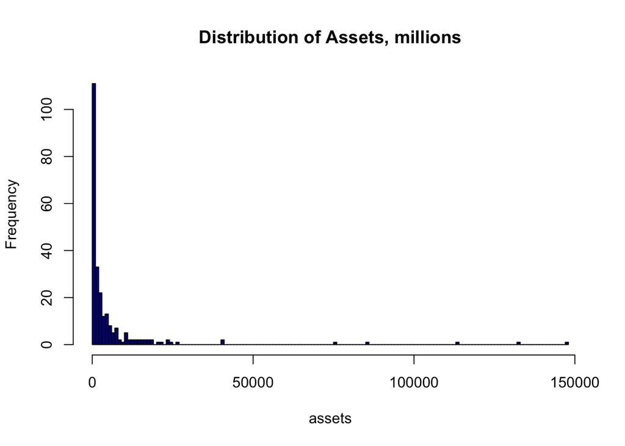

```r
# Histogram (untransformed)
with(Ornstein, hist(assets, breaks='FD', col='navy', main='Distribution of Assets, millions'))
```

Shape suggests a log transform may help the distribution be more approximately normal.

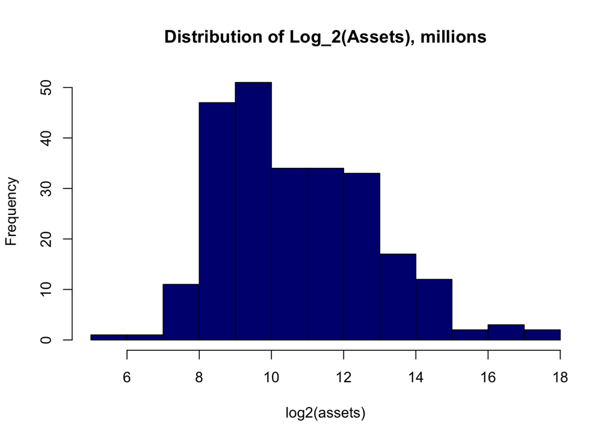

```r
# Histogram (log2 transformed)
with(Ornstein, hist(log2(assets), breaks='FD', col='navy', main='Distribution of Log_2(Assets), millions'))
```

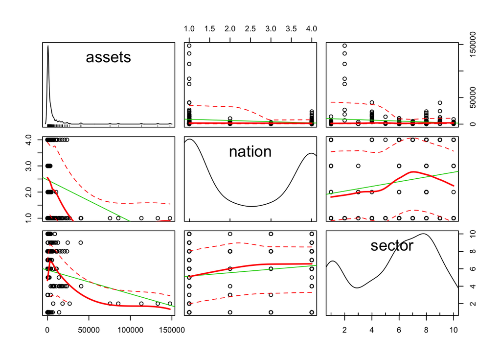

```r
# scatterplot matrices to look at variable correlations
scatterplotMatrix(~assets + nation + sector, data=Ornstein)
```

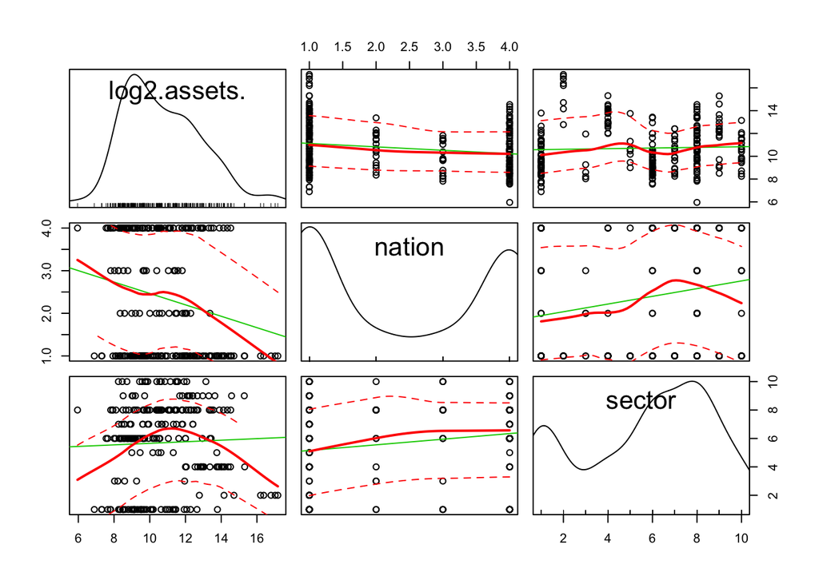

```r
scatterplotMatrix(~log2(assets) + nation + sector, data=Ornstein)
```

*Note: this is NOT a good approach.* Scatterplot matrices don’t make a lot of sense in this case since explanatory variables are categorical. SCM doesn’t display the features very well. Instead, use boxplots:

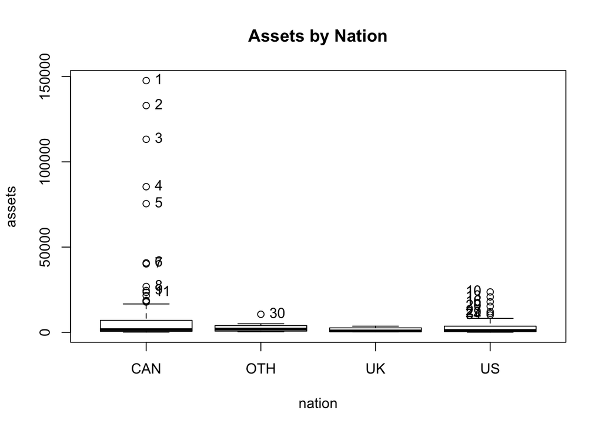

```
##  [1] "1"  "2"  "3"  "4"  "5"  "6"  "7"  "8"  "9"  "11" "30" "10" "13" "16"
## [15] "20" "27" "29" "34"
```

```r
Boxplot(assets ~ nation, data=Ornstein, main='Assets by Nation')
```

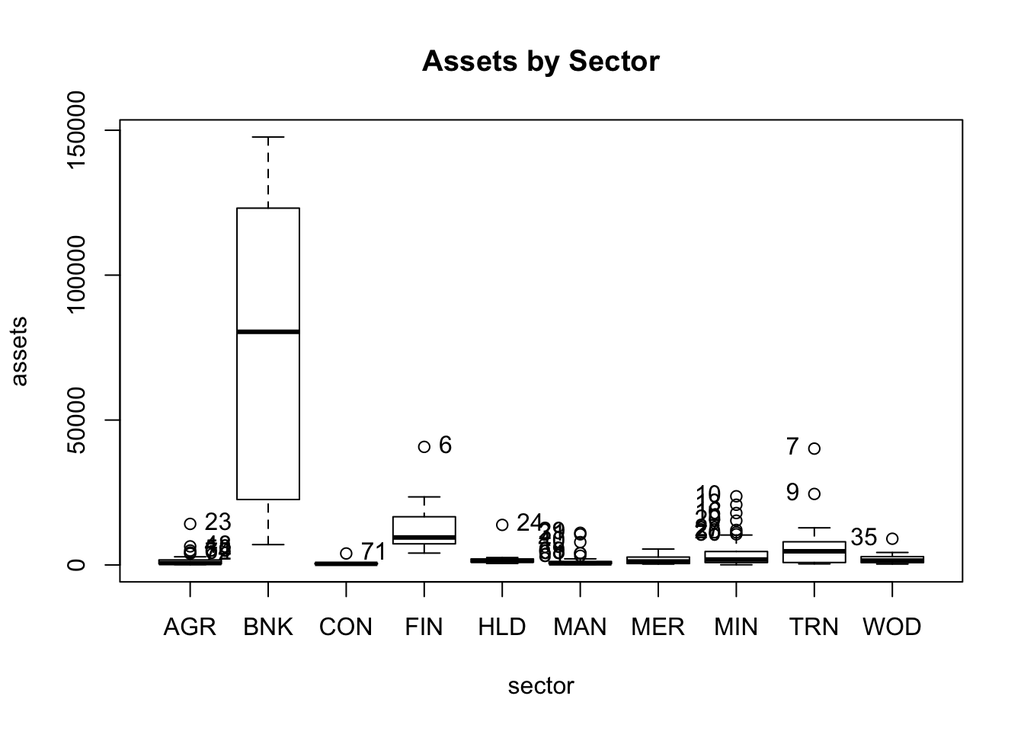

```
##  [1] "23" "48" "58" "64" "72" "71" "6"  "24" "29" "31" "40" "68" "69" "81"
## [15] "10" "13" "16" "20" "27" "28" "30" "7"  "9"  "35"
```

```r
Boxplot(assets ~ sector, data=Ornstein, main='Assets by Sector')
```

*Observations:* Because `assets` is extremely right-skewed, we see the extended tail of points for `CAN`. Banking sector has the largest assets, and also extremely wide distribution. Since data is extremely right-skewed, we may want to look at modified plots: 95th percentile assets; excluding banking.

```r
summary(Ornstein$assets)
```

```
##    Min. 1st Qu.  Median    Mean 3rd Qu.    Max.
##      62     519    1397    5978    4326  147670
```

```r
(pctile95 <- quantile(Ornstein$assets, 0.95))
```

```
##     95%
## 20047.8
```

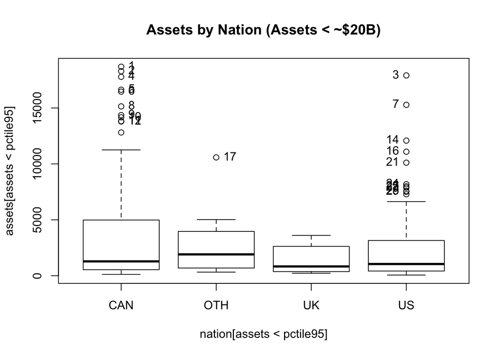

```
##  [1] "1"  "2"  "4"  "5"  "6"  "8"  "9"  "10" "11" "12" "17" "3"  "7"  "14"
## [15] "16" "21" "24" "25" "27" "28" "29"
```

```r
Boxplot(assets[assets<pctile95] ~ nation[assets<pctile95], data=Ornstein, main='Assets by Nation (Assets < ~$20B)')
```

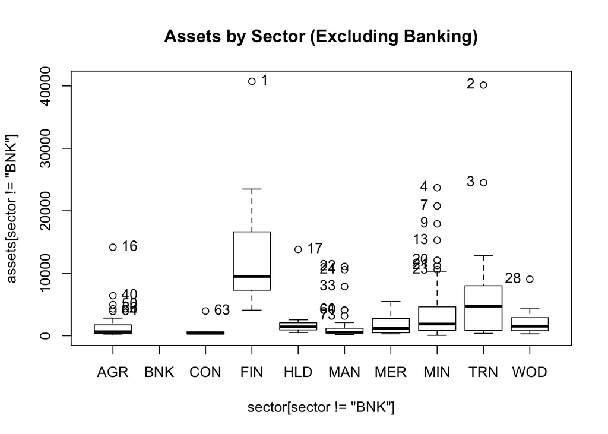

```
##  [1] "16" "40" "50" "56" "64" "63" "1"  "17" "22" "24" "33" "60" "61" "73"
## [15] "4"  "7"  "9"  "13" "20" "21" "23" "2"  "3"  "28"
```

```r
Boxplot(assets[sector!='BNK'] ~ sector[sector!='BNK'], data=Ornstein, main='Assets by Sector (Excluding Banking)')
```

## Poisson Regression

Now, build the regression model. Note that we’re using the log-transformation of `assets`.

```r
poisson_fit <- glm(interlocks ~ log2(assets) + nation + sector, family=poisson(link=log), data=Ornstein)
summary(poisson_fit)
```

```
##
## Call:
## glm(formula = interlocks ~ log2(assets) + nation + sector, family = poisson(link = log),
##     data = Ornstein)
##
## Deviance Residuals:
##     Min       1Q   Median       3Q      Max
## -6.7111  -2.3159  -0.4595   1.2824   6.2849
##
## Coefficients:
##              Estimate Std. Error z value Pr(>|z|)
## (Intercept)  -0.83938    0.13664  -6.143 8.09e-10 ***
## log2(assets)  0.31292    0.01177  26.585  < 2e-16 ***
## nationOTH    -0.10699    0.07438  -1.438 0.150301
## nationUK     -0.38722    0.08951  -4.326 1.52e-05 ***
## nationUS     -0.77239    0.04963 -15.562  < 2e-16 ***
## sectorBNK    -0.16651    0.09575  -1.739 0.082036 .
## sectorCON    -0.48928    0.21320  -2.295 0.021736 *
## sectorFIN    -0.11161    0.07571  -1.474 0.140457
## sectorHLD    -0.01491    0.11924  -0.125 0.900508
## sectorMAN     0.12187    0.07614   1.600 0.109489
## sectorMER     0.06157    0.08670   0.710 0.477601
## sectorMIN     0.24985    0.06888   3.627 0.000286 ***
## sectorTRN     0.15181    0.07893   1.923 0.054453 .
## sectorWOD     0.49825    0.07560   6.590 4.39e-11 ***
## ---
## Signif. codes:  0 '***' 0.001 '**' 0.01 '*' 0.05 '.' 0.1 ' ' 1
##
## (Dispersion parameter for poisson family taken to be 1)
##
##     Null deviance: 3737.0  on 247  degrees of freedom
## Residual deviance: 1547.1  on 234  degrees of freedom
## AIC: 2473.1
##
## Number of Fisher Scoring iterations: 5
```

*Observations:* We can look at the summary to see which are the (omitted) base cases. In this case, it’s `nation=CAN` and `sector=AGR`. Also, remember that the coefficients are for the *linear predictor*, ie. for the *log*(counts). We have to exponentiate to get effect on the counts.

Let’s look at the frequency table.

```r
# Create frequency table
with(Ornstein, table(nation, sector))
```

```
##       sector
## nation AGR BNK CON FIN HLD MAN MER MIN TRN WOD
##    CAN  27   8   2  17   6  14  13   9  11  10
##    OTH   2   0   2   1   0   2   0  10   0   1
##    UK    4   0   1   0   0   3   0   6   0   3
##    US   14   0   0   4   1  29   7  29   7   5
```

*Observations:* Our reference category (CAN + AGR) has a substantial number of observations. This is good; if our base case had a small number, we might be better off changing the base case.

** Analysis of Deviance

```r
Anova(poisson_fit)
```

```
## Analysis of Deviance Table (Type II tests)
##
## Response: interlocks
##              LR Chisq Df Pr(>Chisq)
## log2(assets)   731.21  1  < 2.2e-16 ***
## nation         276.04  3  < 2.2e-16 ***
## sector         102.71  9  < 2.2e-16 ***
## ---
## Signif. codes:  0 '***' 0.001 '**' 0.01 '*' 0.05 '.' 0.1 ' ' 1
```

*Observations:* Capital `Anova` does a Type II analysis. All predictors have high significance.

## Interpretation of Coefficients

Coefficients of the model are interpreted as effects on the log-count scale (ie. the scale of the linear predictor). Exponentiating the coefficients produces the multiplicative effects on the count scale.

```r
exp(coef(poisson_fit))
```

```
##  (Intercept) log2(assets)    nationOTH     nationUK     nationUS
##    0.4319777    1.3674101    0.8985317    0.6789410    0.4619077
##    sectorBNK    sectorCON    sectorFIN    sectorHLD    sectorMAN
##    0.8466116    0.6130649    0.8943943    0.9852027    1.1296019
##    sectorMER    sectorMIN    sectorTRN    sectorWOD
##    1.0635096    1.2838282    1.1639375    1.6458464
```

*Observations:* a corporation that is twice the size (based on assets) of another one has an estimated 36.7% higher number of interlocks, holding all other factors constant.

A US firm on average maintains only 46.2% as many interlocks as a Canadian firm, holding all other factors constant.

## Visualize the Effects of Changes in Explanatory Variables

Effects plots show how estimated responses change with predictor values. (These are not diagnostic plots.)

One variable at a time is changed, while others are held constant at “typical” values. (For continuous variables, at their mean; for factor variables, sets proportional distribution to match that observed in data.)

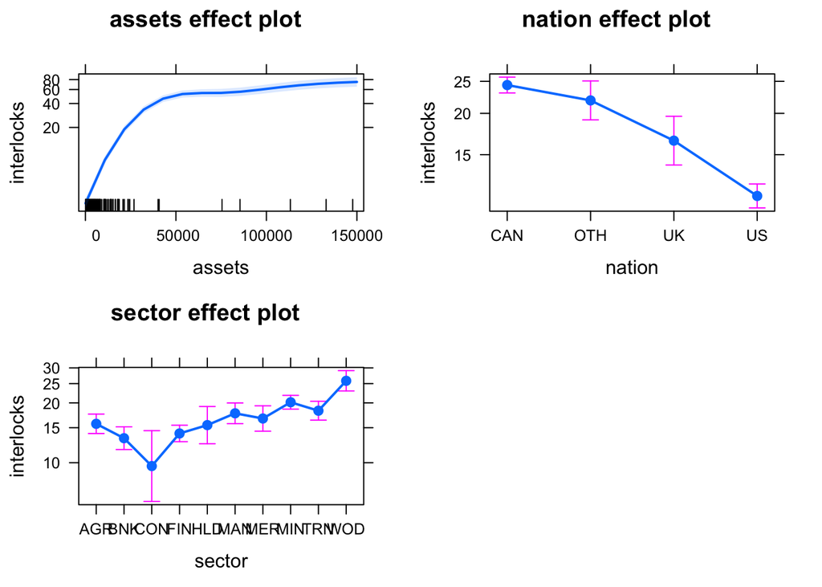

```r
plot(allEffects(poisson_fit, default.levels=50))
```

The y-axis is on the scale of the linear predictor (in this case, `log`). The bands around the means are 95% confidence intervals, calculated using standard errors from the model. From the y-axis range of data, we can get a sense of strength of each predictor’s effect; we can also get a sense of level of uncertainty in the estimates.

## Model Diagnostics

The diagnostic plots for a Poisson model are different than for linear regression. These plots use Pearson residuals. There is one plot per explanatory variable, as well as one for the linear predictor. We want to see that there are *no systematic patterns* between residuals and the explanatory variables. We should look for nonlinear trends (esp. curved splines), trends in variation across the graph, and outlier points. Box plots should show roughly similar centers and spreads.

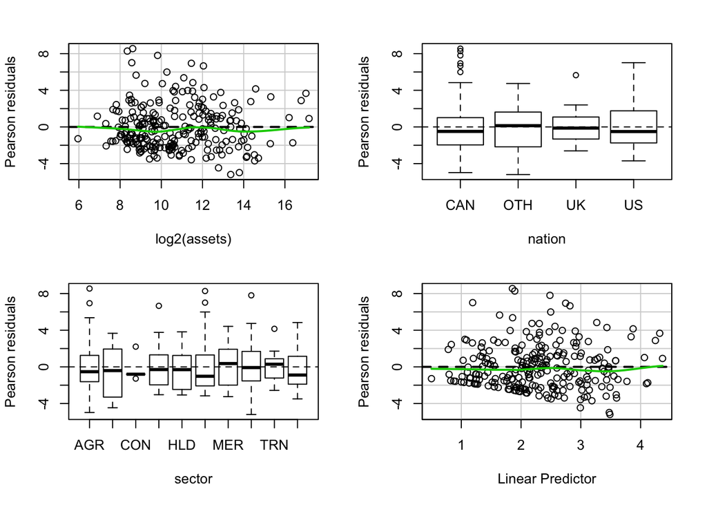

```
##              Test stat Pr(>|t|)
## log2(assets)    15.745        0
## nation              NA       NA
## sector              NA       NA
```

```r
residualPlots(poisson_fit, layout=c(2,2))
```

*Observations:* not much pattern observed here. The *lack of fit test* results are also displayed (only meaniningful for continuous variables, otherwise `NA`). A large p-value means we cannot reject the null hypothesis that the model fits the data well. Here, the p-value of ~0 indicates a lack of fit. (**TODO: confirm this interpretation.**)